# P1 Navigation Report

## Description of the Algorithm

My goal in this project was to learn how to use the Deep Q Network (DQN) algorithm, and some of its improvements that were described in our lessons. A reviewer will likely not find much creativity in my implementation, as I started from the base code in our lesson; however I found it very enlightening and useful to start from there and try to implement some of the additional algorithmic wrinkles that were introduced to us. As you will see, the base DQN code is able to "solve" the environment, and the additional features that I added were not able to significantly improve on the situation. I will describe what I did below.

## Over-optimisitic Plan

My initial plan was to try to implement as all of the algorithmic features listed in the lesson:

1. DQN
2. Double DQN
3. Prioritized Experience Replay
4. Dueling DQN
5. Distributional DQN
6. Noisy DQN

What I actually did was polish up an implementation of (1), tune its hyper-parameters, and give a college-try for 2-4. I couldn't understand 5 and 6 enough to implement them yet.

## Deep Q Network

We know from our lessons on reinforcement learning that the state-action value function $Q^{\pi}(s, a)$ is the expected sum of rewards for an agent acting according to a policy $\pi$, that is in state $s$ and takes an action $a$. This mapping of states and actions to values is at the heart of reinforcement learning, and we have studied algorithms such as SARSA for determining $Q$ (and from it, an optimal policy $\pi$). Whereas the traditional algorithms break down for very large or continuous environments, [Minh and coworkers](https://storage.googleapis.com/deepmind-media/dqn/DQNNaturePaper.pdf) elaborated on techniques to stabily approximate $Q$ with a neural network, which allows Q-learning to be applied in these more complex domains. Minh's main contributions were the description of two important features that improved the stability of the training of $Q$. This was the use of experience-replay, where state-action-reward-next state-next action transitions are stored in a buffer and recalled for training randomly, and fixed-Q targets, where two sets of neural network parameters describing $Q$ are utilized. Experience-replay drastically improves the efficiency of training and also decorrelates sequences of states from each other, allowing to explore a wider range of solutions. Fixed-Q targets improve the stability of training.

### Double DQN

[Double-DQN](https://arxiv.org/pdf/1509.06461.pdf) is a technique that solves a problem with the original DQN algorithm, whereby the same $Q$ network is used to both choose actions and evaluate them. This process makes it more likely that values are overestimated. Faster training and better results were demonstrated in some cases by using two sets of network parameters; one to choose an action, and another one to evaluate it. This should be fairly simple, because the original DQN algorithm already has two sets of networks for the fixed-Q feature.

Below we can see how the normal DQN algorithm evalutes the value of a state-action pair. The state $s^{'}=nextstates$ is the input to the network, and the action-value is evaluated by taking the action with the maximum value. This evaluation leads to the overestimation of the values.

```
# use the standard dqn algorithm, where the same network is used to determine the greedy policy AND determine its value
# Get max predicted Q values (for next states) from target model
# the network outputs a tensor BATCH_SIZE x ACTION_SIZE.  Using max(1) finds the
# maximum value along the column dimension, returning the BATCH_SIZE maximum values and
# their indices.  The [0] takes the maximum values (and not their indices), and unsqueeze
# makes that vector into a tensor of BATCH_SIZE x 1
Q_targets_next = self.qnetwork_target(next_states).detach().max(1)[0].unsqueeze(1)
```

My implementation of the double DQN feature is shown below. Here the local network is used to choose a value, and it is passed to the target network to evaluate that value.

```
# "For each update, one set of weights is used to determine the greedy policy and the other to determine its value."
# the next line evaluates the q for the next states and gets the indices of the best actions with the max(1)[1] call.
# unsqueeze makes them a batch_size x 1 tensor to be used with gather
local_net_actions = self.qnetwork_local(next_states).detach().max(1)[1].unsqueeze(1)
# determine the value of these actions
Q_targets_next = self.qnetwork_target(next_states).gather(1, local_net_actions)
```

### Prioritized Experience Replay

[Prioritized experience replay](https://arxiv.org/abs/1511.05952) is a technique to improve the experience replay mechanism by biasing the random sampling towards the transitions that have the most error. This is a natural extension of the method, but in practice seems difficult to implement efficiently. I tried to get the hang of it with a naive implementation that uses random.choices, where the transitions in memory are sampled according to a probability distribution, in the weights parameter. This implementation is inefficient, because I believe that random.choices needs to sort the the indices based on their weights. The paper describes, without enough detail for me, some ways that they accomplished this more efficiently.

```
# get a set of random indices, weighted by the sampling weights
current_size = len(self.memory)
random_indices = random.choices(self.indices[:current_size], weights=self.sampling_weights[:current_size], k=self.batch_size)
# get the experiences corresponding to these indices
experiences = []
for idx in random_indices:
    experiences.append(self.memory[idx])
```

The sampling weights can be calculated in a few different ways. One way calculates priorities based on the transitions' rank error, while the other way uses a priority proportional to the error. I tried to implement the proportional mechanism, but I realize now that my weights were normalized to the mini-batch, and not the entire memory buffer. This is likely an error. My implementation of the algorithm learned slower than the baseline mechanism, but I know that this could be improved.

### Dueling DQN

[Dueling DQN](https://arxiv.org/pdf/1511.06581.pdf) is a technique that estimates $Q$ with two separate networks: one that estimates the value of a state $V(s)$, and another that estimates the advantage of an action taken in that state, $A(s, a)$. This decoupling of the state and advantage is supposed to allow for faster and better training especially when the action space is very large. I implemented this in the `DuelingQNetwork` class. We calculate $Q(s, a) = V(s) + (A(s,a) - \frac{1}{|\mathcal{A}|}\sum\limits_{a^{'}} A(s,a^{'})))$ in the forward function of the network.

```
def forward(self, state):
    '''
        Evaluate each network and combine using equation 9 from the paper.
    '''
    # batch_size x 1
    value = self.value_net(state).squeeze(0)
    # batch_size x action_size
    advantage = self.advantage_net(state)
    # average over the action dimension, batch_size x 1
    advantage_mean = torch.mean(advantage, dim=1).unsqueeze(1)

    return value + (advantage - advantage_mean)
```

### Other Features

I wanted to implement [Noisy DQN](https://arxiv.org/abs/1706.10295) and [Distributional DQN](https://arxiv.org/abs/1707.06887), but didn't understand them well enough to implement them yet!

### Results

Below you will find some results that I generated, in particular a comparison of several models and a tuning of the hyperparameters.

```python
import pickle
import matplotlib.pyplot as plt
import utilities as utils
import numpy as np
import torch
utils.setup_environment();

# the lab instructions state that an average score of 13 over 100 iterations counts as "solving" the environment
SOLVED_SCORE = 13

def load_scores(file_name):
    return torch.load(file_name)['scores']

def moving_average(x, w):
    return np.convolve(x, np.ones(w), 'valid') / w

def plot_hypertune_iteration(model_file_names, model_labels, title):
    model_scores = [load_scores(f) for f in model_file_names]
    fig,ax = plt.subplots()
    for scores, label in zip(model_scores, model_labels):
        ax.plot(moving_average(scores, 15), label=label)

    ax.axhline(y=SOLVED_SCORE, linestyle='--', color='grey', alpha=0.5, label="'Solved' Reward")
    ax.legend()
    ax.set_xlabel('Epoch')
    ax.set_ylabel('Average Reward (Smoothed)')
    ax.set_title(title)
```

## Hyper-parameter Tuning

As described in my README.md file, when the arguments are given as lists, my program will perform training on the cartesian product of the listed parameters.

```
{
    "algorithms": [
        [], ["double_dqn"], ["prioritized_replay"], ["double_dqn", "prioritized_replay"]
    ],
    "replay_buffer_size": 1e5,
    "batch_size": 64,
    "gamma": [0.99],
    "tau": 1e-3,
    "learning_rate": 5e-4,
    "learn_every": 4,
    "num_episodes": 2000,
    "max_time": 1000,
    "eps_start": 1.0,
    "eps_end": 0.01,
    "eps_decay": 0.995,
    "alpha": 0.5,
    "beta": 0.5
}
```

### Exploration of Algorithms

Such as they were, I have made an implementation of the base DQN, double-DQN, and Prioritized Replay features. The double-DQN showed no effect on the baseline DQN result, but did speed up the learning of the Prioritized Replay. However the Prioritized Replay learned much slower at the beginning that the other techniques. This might be expected due to the networks initially trying to learn from the toughest, highest error transitions. Eventually the network makes a breakthrough and the scores rise very quickly, with a result just slighly higher than the baseline DQN.

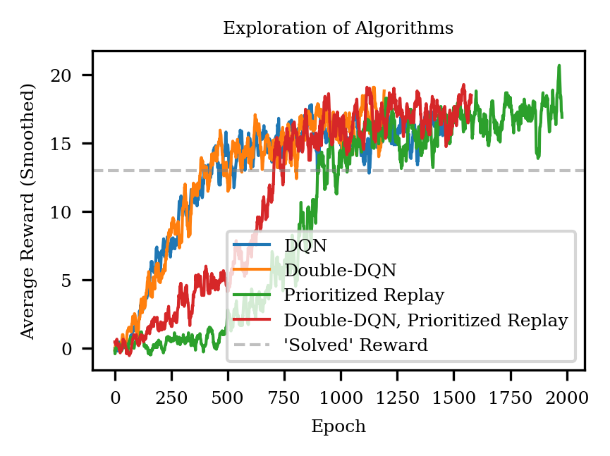

```python
plot_hypertune_iteration( [
    'model_baseline.pth',
    'model_dqn.pth',
    'model_pr.pth',
    'model_dqn_pr.pth',
], [
    'DQN',
    'Double-DQN',
    'Prioritized Replay',
    'Double-DQN, Prioritized Replay'
],
    'Exploration of Algorithms'
)
```

### Hyper-parameter Tuning Results - Learning Rate = 1e-4

Next I optimized the parameters for the baseline DQN algorithm, starting with the learning rate of the local Q network.

```
{
    "base_name": "baseline_hyperparams_lr",
    "algorithms": [
        []
    ],
    "replay_buffer_size": 1e5,
    "batch_size": 64,
    "gamma": [0.99],
    "tau": 1e-3,
    "learning_rate": [1e-5, 1e-4, 5e-4, 1e-3, 1e-2],
    "learn_every": [4],
    "num_episodes": 2000,
    "max_time": 1000,
    "eps_start": 1.0,
    "eps_end": 0.01,
    "eps_decay": 0.995,
}
```

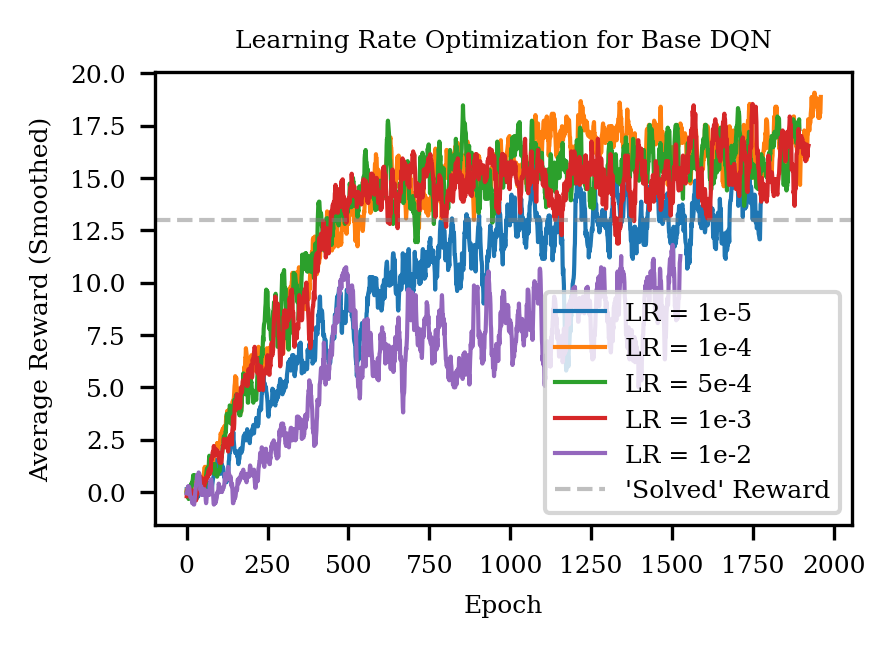

```python
plot_hypertune_iteration( [
    'baseline_hyperparams_lr_0.pth',
    'baseline_hyperparams_lr_1.pth',
    'baseline_hyperparams_lr_2.pth',
    'baseline_hyperparams_lr_3.pth',
    'baseline_hyperparams_lr_4.pth',
], [
    'LR = 1e-5',
    'LR = 1e-4',
    'LR = 5e-4',
    'LR = 1e-3',
    'LR = 1e-2',
],
    'Learning Rate Optimization for Base DQN'
)
```

### Hyper-parameter Tuning Results - Tau = 1e-3

This parameter influences how fast the target network is updated towards the local network in the DQN scheme.

```
{
    "base_name": "baseline_hyperparams_tau",
    "algorithms": [
        []
    ],
    "replay_buffer_size": 1e5,
    "batch_size": 64,
    "gamma": [0.99],
    "tau": [1e-5, 1e-4, 1e-3, 1e-2],
    "learning_rate": [1e-4],
    "learn_every": [4],
    "num_episodes": 2000,
    "max_time": 1000,
    "eps_start": 1.0,
    "eps_end": 0.01,
    "eps_decay": 0.995,
    "alpha": 0.5,
    "beta": 0.5
}
```

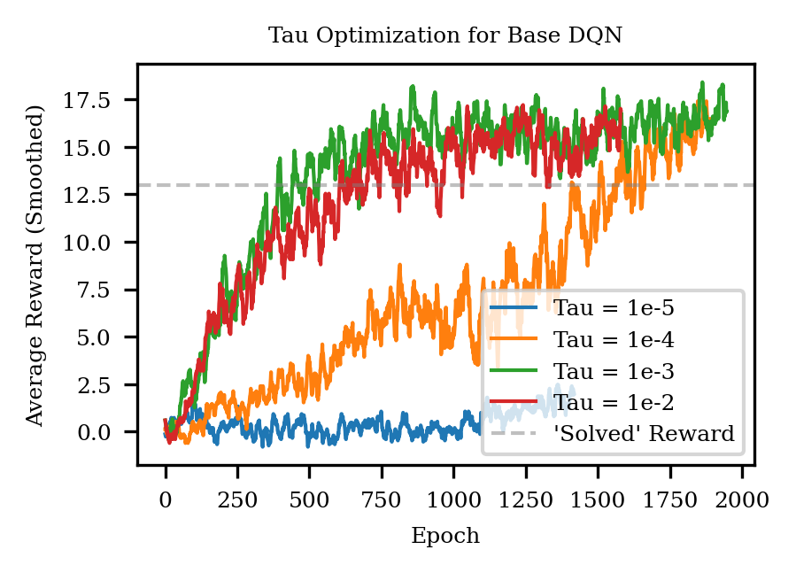

```python
plot_hypertune_iteration( [
    'baseline_hyperparams_tau_0.pth',
    'baseline_hyperparams_tau_1.pth',
    'baseline_hyperparams_tau_2.pth',
    'baseline_hyperparams_tau_3.pth',
], [
    'Tau = 1e-5',
    'Tau = 1e-4',
    'Tau = 1e-3',
    'Tau = 1e-2',
],
    'Tau Optimization for Base DQN'
)
```

### Hyper-parameter Tuning Results - Gamma = 0.99+

```
{
    "base_name": "baseline_hyperparams_gamma",
    "algorithms": [
        []
    ],
    "replay_buffer_size": 1e5,
    "batch_size": 64,
    "gamma": [0.8, 0.9, 0.95, 0.99, 0.999, 1.0],
    "tau": 1e-3,
    "learning_rate": 1e-4,
    "learn_every": 4,
    "num_episodes": 2000,
    "max_time": 1000,
    "eps_start": 1.0,
    "eps_end": 0.01,
    "eps_decay": 0.995,
    "alpha": 0.5,
    "beta": 0.5
}
```

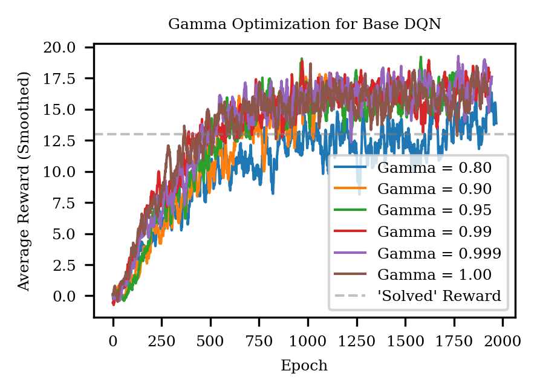

```python
plot_hypertune_iteration( [
    'baseline_hyperparams_gamma_0.pth',
    'baseline_hyperparams_gamma_1.pth',
    'baseline_hyperparams_gamma_2.pth',
    'baseline_hyperparams_gamma_3.pth',
    'baseline_hyperparams_gamma_4.pth',
    'baseline_hyperparams_gamma_5.pth',
], [
    'Gamma = 0.80',
    'Gamma = 0.90',
    'Gamma = 0.95',
    'Gamma = 0.99',
    'Gamma = 0.999',
    'Gamma = 1.00',
],
    'Gamma Optimization for Base DQN'
)
```